# STAT 531 Portfolio

Author

Tillman Erb

Published

October 29, 2024

**My Grade:** I believe my grade equivalent to course work evidenced below to be an **A**.

**Learning Objective Evidence:** In the code chunks below, provide code from Lab or Challenge assignments where you believe you have demonstrated proficiency with the specified learning target. Be sure to specify **where** the code came from (e.g., Lab 4 Question 2).

**To Do List: Complete Before Final Portfolio**

- Filter a Dataframe using a factor (forcats)
- Joins
  - Anti Join
  - Full Join
- Function formatting
- Function stops
- across()
- DVS-7
- PE-1 (most)
- PE-2
- PE-3
- DSSM-1

## Working with Data

**WD-1: I can import data from a *variety* of formats (e.g., csv, xlsx, txt, etc.).**

- `csv`

```r
#Lab 3 Question 2
evals <- read_csv(file = here::here("data","teacher_evals.csv"))
```

- `xlsx`

Check-in 2.3

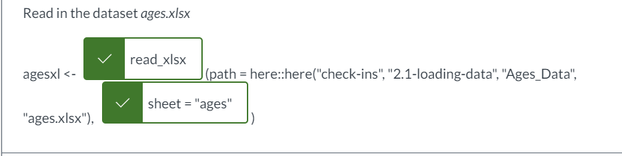

- `txt`

Check-in 2.3

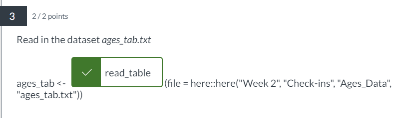

**WD-2: I can select necessary columns from a dataset.**

```r
# Lab 4 Question 5
income_cc <- ca_childcare |>
  filter(study_year == 2018) |>
  group_by(region) |>
  summarize(median_weekly_cc_price = median(mc_infant)) |>
  arrange(median_weekly_cc_price) |>
  inner_join(select(median_inc, -`2008`)) |> #Selecting all columns except "2008"
  rename(median_household_income =`2018`)

#Lab 3 Question 2
evals_cleaned <- evals |>
  select(course_id:SET_score_avg,
         percent_failed_cur,
         academic_degree:gender)
#Selected columns using a variety of syntaxes
```

**WD-3: I can filter rows from a dataframe for a *variety* of data types (e.g., numeric, integer, character, factor, date).**

- numeric

```r
#Lab 5 "Checking interviews for these two IDs"
witness_test <- interview |>
  filter(person_id %in% c(16371, 14887))
```

- character – specifically a string (example must use functions from **stringr**)

```r
#Lab 5 "Fitering Membership check in times"
membership_ids <- get_fit_now_check_in |>
  mutate(check_in_date = ymd(check_in_date)) |>
  filter(check_in_date == ymd(20180109),
         str_detect(membership_id, "^48Z")) #Checking for a string that begins with "^48z"
```

- factor
- date (example must use functions from **lubridate**)

```r
#Lab 5 Fitering Membership check in times
membership_ids <- get_fit_now_check_in |>
  mutate(check_in_date = ymd(check_in_date)) |>
  filter(check_in_date == ymd(20180109), #Filtering for 1/9/2018, converting from int to datetime
         str_detect(membership_id, "^48Z"))
```

**WD-4: I can modify existing variables and create new variables in a dataframe for a *variety* of data types (e.g., numeric, integer, character, factor, date).**

- numeric (using `as.numeric()` is not sufficient)

```r
#Challenge 3 Question 1
teacher_evals_compare <- evals |>
  filter(question_no == 903) |>
  mutate(SET_level = if_else(SET_score_avg >=4,
                             'excellent',
                             'standard'),
         sen_level = if_else(seniority <= 4,
                             'junior',
                             'senior'))
```

- character – specifically a string (example must use functions from **stringr**)

```r
#Lab 4 Question 3

ca_childcare <- ca_childcare |>
  mutate(county_name = str_remove(county_name, " County"), #Used str_remove to remove "County" from the county name.
        region = fct_collapse(county_name,
        "Superior California" = c("Butte", "El Dorado", "Colusa", "Glenn", "Lassen", "Modoc", "Nevada", "Placer", "Plumas", "Sacramento", "Shasta", "Sierra", "Siskiyou", "Sutter", "Tehama", "Yolo", "Yuba"),
        "North Coast" = c("Del Norte", "Humboldt", "Lake", "Mendocino", "Napa", "Sonoma", "Trinity"),
        "San Francisco Bay Area" = c("Alameda", "Contra Costa", "Marin", "San Francisco", "San Mateo", "Santa Clara", "Solano"),
        "Northern San Joaquin Valley" = c("Alpine", "Amador", "Calaveras", "Madera", "Mariposa", "Merced", "Mono", "San Joaquin", "Stanislaus", "Tuolumne"),
        "Central Coast" = c("Monterey", "San Benito", "San Luis Obispo", "Santa Barbara", "Santa Cruz", "Ventura"),
        "Southern San Joaquin Valley" = c("Fresno", "Inyo", "Kern", "Kings", "Tulare"),
        "Inland Empire" = c("Riverside", "San Bernardino"),
        "Los Angeles County" = "Los Angeles",
        "Orange County" = "Orange",
        "San Diego County" = c("Imperial", "San Diego")
        ), .before = state_abbreviation)
```

- factor (example must use functions from **forcats**)

```r
#Lab 4 Question 6

plot_data <- ca_childcare |>
  select(county_name, region, study_year, mc_infant, mc_toddler, mc_preschool) |>
  pivot_longer(cols = c(mc_infant, mc_toddler, mc_preschool),
               names_to = "cc_type",
               values_to = "wkly_med_price"
              ) |>
  mutate(cc_type = fct_recode(cc_type,
      "Infant" = "mc_infant",
      "Toddler" = "mc_toddler",
      "Preschool" = "mc_preschool"))
#Recoding factors in a given column
```

- date (example must use functions from **lubridate**)

```r
#Lab 5 Fitering Membership check in times
membership_ids <- get_fit_now_check_in |>
  mutate(check_in_date = ymd(check_in_date)) #Mutating integer to date format using ymd() function
```

**WD-5: I can use mutating joins to combine multiple dataframes.**

- `left_join()`

```r
# Lab 5 'Getting ids of red-haired suspects above'
mfh_ids <- murder_for_hire_lic_ids |>
  left_join(person, by = c("id" = "license_id")) |>
  select(id = id.y)

mfh_ids
```

- `right_join()`

```r
#Lab 5 'Getting the assassin's employer's name'
id_1 <- person |>
  right_join(id, by = c("id" = "person_id"))
```

- `inner_join()`

```r
#Lab 4 Question 2
ca_childcare <- counties |>
  filter(state_abbreviation == 'CA') |>
  inner_join(childcare_costs)
```

- `full_join()`

**WD-6: I can use filtering joins to filter rows from a dataframe.**

- `semi_join()`

```r
# Lab 5 'Checking interviews for IDs found in section above'
witness_test <- interview |>
  semi_join(address_ids, by = (c("person_id" = "id")))
```

- `anti_join()`

**WD-7: I can pivot dataframes from long to wide and visa versa**

- `pivot_longer()`

```r
#Lab 4 Question 6

plot_data <- ca_childcare |>
  select(county_name, region, study_year, mc_infant, mc_toddler, mc_preschool) |>
  pivot_longer(cols = c(mc_infant, mc_toddler, mc_preschool),
               names_to = "cc_type",
               values_to = "wkly_med_price"
              )
```

- `pivot_wider()`

```r
#Lab 4 Question 4

median_inc <- ca_childcare |>
  filter(study_year %in% c(2008, 2018)) |>
  group_by(region, study_year) |>
  summarize(median_household_income = median(mhi_2018)) |>
  pivot_wider(names_from = study_year, values_from = median_household_income) #pivoting wider here
```

## Reproducibility

**R-1: I can create professional looking, reproducible analyses using RStudio projects, Quarto documents, and the here package.**

I’ve done this in the following provided assignments:

Lab 5 (see .html file in portfolio GitHub repository)

**R-2: I can write well documented and tidy code.**

- Example of **ggplot2** plotting

```r
# Lab 4 Question 6
# Used named arguments and newlines throughout for clear documentation of code

ggplot(data = plot_data, mapping = aes(x = study_year,
                                       y = wkly_med_price,
                                       color = fct_reorder2(.f = region,
                                                            .x = study_year,
                                                            .y = wkly_med_price)
                                       )
       ) +
  geom_point() +
  geom_smooth(method = 'loess') +
  facet_grid(~ factor(cc_type, levels = c("Infant", "Toddler", "Preschool"))) +
  labs(x = "Study Year",
       y = NULL,
       title = "Weekly Median Price for Center-Based Childcare ($)",
       color = "California Region") +
  scale_y_continuous(limits = c(0,500)) + #http://www.sthda.com/english/wiki/ggplot2-axis-ticks-a-guide-to-customize-tick-marks-and-labels
  scale_x_continuous(breaks = seq.int(2008, 2018, by = 2)) + #https://www.geeksforgeeks.org/get-a-list-of-numbers-in-the-specified-range-in-r-programming-seq-int-function/
  theme(aspect.ratio = 1.4,
        axis.text.x = element_text(size=6),
        axis.text.y = element_text(size=8),#https://stackoverflow.com/questions/14942681/change-size-of-axes-title-and-labels-in-ggplot2
        panel.spacing.x = unit(1, "lines")) + #https://ggplot2.tidyverse.org/reference/theme.html
  scale_colour_viridis_d()
```

- Example of **dplyr** pipeline

```r
# Lab 4 Question 6
# Again used named arguments and newlines to improve tidiness and ensure code is properly documented

plot_data <- ca_childcare |>
  select(county_name, region, study_year, mc_infant, mc_toddler, mc_preschool) |>
  pivot_longer(cols = c(mc_infant, mc_toddler, mc_preschool),
               names_to = "cc_type",
               values_to = "wkly_med_price"
              ) |>
  mutate(cc_type = fct_recode(cc_type,
      "Infant" = "mc_infant",
      "Toddler" = "mc_toddler",
      "Preschool" = "mc_preschool"))
```

- Example of function formatting

**R-3: I can write robust programs that are resistant to changes in inputs.**

- Example – any context

```r
# Lab 4 Question 5
#Joined a wrangled ca_childcare with a previous dataframe, median_inc, resulting in a dataframe with the median household income and median weekly center-based childcare price. If the data were to change for this year, the user would be able to assess, based off the table, if the region with the lowest income also has the lowest childcare prices.

income_cc <- ca_childcare |>
  filter(study_year == 2018) |>
  group_by(region) |>
  summarize(median_weekly_cc_price = median(mc_infant)) |>
  arrange(median_weekly_cc_price) |>
  inner_join(select(median_inc, -`2008`)) |>
  rename(median_household_income =`2018`)
```

- Example of function stops

## Data Visualization & Summarization

**DVS-1: I can create visualizations for a *variety* of variable types (e.g., numeric, character, factor, date)**

- at least two numeric variables

```r
#Lab 4 Question 7
ca_childcare_2018 |>
  ggplot(mapping = aes(y = mc_infant,
                       x = mhi_2018)) +
  geom_point() +
  geom_smooth(method = "lm") +
  labs(title = "Median Household Income ($) versus Median Weekly Infant
                Center-Based Childcare Price ($)",
       x = "2018 CA Regional Median Household Income ($)",
       y = NULL,
       subtitle = "2018 CA Regional Median Childcare Price ($)") +
  scale_x_continuous(labels = label_dollar()) + #https://scales.r-lib.org/reference/label_dollar.html
  scale_y_continuous(labels = label_dollar())
```

- at least one numeric variable and one categorical variable

```r
#Lab 2 Question 10

ggplot(data = surveys,
       mapping = aes(x = species,
                     y = weight)) +
geom_boxplot(outliers = FALSE) +
geom_jitter(color = 'steelblue',
            'alpha' = 0.3
            ) +
labs(x = "Species of Animal",
     y = "Weight (g)"
) +
#https://stackoverflow.com/questions/1330989/rotating-and-spacing-axis-labels-in-ggplot2
theme(axis.text.x = element_text(angle = 45, hjust = 1))
```

- at least two categorical variables

```r
#Challenge 2 'Spicy' Level

ggplot(data = surveys,
       mapping = aes(x = species,
                     y = weight)) +
geom_jitter(mapping = aes(color = genus),
            'alpha' = 0.3
            ) +
geom_boxplot(outliers = FALSE) +
labs(x = "Species",
     y = "Weight (g)"
) +
theme(axis.text.x = element_text(angle = 45, hjust = 1)) +
scale_colour_viridis_d()
```

- dates (timeseries plot)

```r
#Lab 4 Question 6

ggplot(data = plot_data, mapping = aes(x = study_year,
                                       y = wkly_med_price,
                                       color = fct_reorder2(.f = region,
                                                            .x = study_year,
                                                            .y = wkly_med_price)
                                       )
       ) +
  geom_point() +
  geom_smooth(method = 'loess') +
  facet_grid(~ factor(cc_type, levels = c("Infant", "Toddler", "Preschool"))) +
  labs(x = "Study Year",
       y = NULL,
       title = "Weekly Median Price for Center-Based Childcare ($)",
       color = "California Region") +
  scale_y_continuous(limits = c(0,500)) + #http://www.sthda.com/english/wiki/ggplot2-axis-ticks-a-guide-to-customize-tick-marks-and-labels
  scale_x_continuous(breaks = seq.int(2008, 2018, by = 2))
```

**DVS-2: I use plot modifications to make my visualization clear to the reader.**

- I can ensure people don’t tilt their head

```r
#Lab 2 Question 2
#Put y axis label as a subheader so people don't tilt their heads

ggplot(data = teacher_evals_compare, mapping = aes(x = sen_level,
                                                   fill = SET_level)) +
  geom_bar() +
  scale_fill_manual(values = c("#0072B2","#E69F00")) + #https://ggplot2.tidyverse.org/reference/scale_manual.html
  labs(x = "Seniority of Instructor",
     y = "",
     title = "Number of Sections",
     fill = 'SET Level' #https://stackoverflow.com/questions/14622421/how-to-change-legend-title-in-ggplot,
     )
```

- I can modify the text in my plot to be more readable

```r
#Challenge 2 Question 3
#Placed and changed size of genus labels to ensure readibility. See large annotate block towards end of snippet

ggplot(data = surveys,
       mapping = aes(y = species,
                     x = weight)) +
geom_jitter(mapping = aes(color = genus),
            'alpha' = 0.3
            ) +
geom_boxplot(outliers = FALSE) +
labs(y = "Weight (g)",
     x = "Species"
) +
theme(axis.text.x = element_text(angle = 45, hjust = 1), legend.position = "none") +
scale_colour_viridis_d() +
  labs(x = "Weight (g)",
       y = "",
       subtitle = "Species",
       title = "Rodent Weight by Species") +
annotate("text", y = 2, x = 250, size = 3, label = "Chaetodipus") +
annotate("text", y = 13, x = 250, size = 3, label = "Dipodomys") +
annotate("text", y = 1, x = 25, size = 3, label = "Neotoma") +
annotate("text", y = 14, x = 250, size = 3, label = "Onychomys") +
annotate("text", y = 4, x = 250, size = 3, label = "Perognathus") +
annotate("text", y = 3, x = 250, size = 3, label = "Peromyscus") +
annotate("text", y = 9, x = 250, size = 3, label = "Reithrodontomys") +
annotate("text", y = 6, x = 250, size = 3, label = "Sigmodon") +
annotate("text", y = 5, x = 250, size = 3, label = "Reithrodontomys") +
annotate("text", y = 12, x = 250, size = 3, label = "Chaetodipus") +
annotate("text", y = 11, x = 250, size = 3, label = "Dipodomys") +
annotate("text", y = 10, x = 250, size = 3, label = "Dipodomys") +
annotate("text", y = 7, x = 250, size = 3, label = "Perognathus") +
annotate("text", y = 8, x = 250, size = 3, label = "Peromyscus")
```

- I can reorder my legend to align with the colors in my plot

```r
#Lab 4 Question 6
#Used fct_reorder2 to reorder legend based off plot values

plot_data <- ca_childcare |>
  select(county_name, region, study_year, mc_infant, mc_toddler, mc_preschool) |>
  pivot_longer(cols = c(mc_infant, mc_toddler, mc_preschool),
               names_to = "cc_type",
               values_to = "wkly_med_price"
              ) |>
  mutate(cc_type = fct_recode(cc_type,
      "Infant" = "mc_infant",
      "Toddler" = "mc_toddler",
      "Preschool" = "mc_preschool"))

ggplot(data = plot_data, mapping = aes(x = study_year,
                                       y = wkly_med_price,
                                       color = fct_reorder2(.f = region,
                                                            .x = study_year,
                                                            .y = wkly_med_price)
                                       )
       )
```

**DVS-3: I show creativity in my visualizations**

- I can use non-standard colors

```r
#Challenge 2 Question 3
#Used scale_colour_viridis_d()

ggplot(data = surveys,
       mapping = aes(y = species,
                     x = weight)) +
geom_jitter(mapping = aes(color = genus),
            'alpha' = 0.3
            ) +
geom_boxplot(outliers = FALSE) +
labs(y = "Weight (g)",
     x = "Species"
) +
theme(axis.text.x = element_text(angle = 45, hjust = 1), legend.position = "none") +
scale_colour_viridis_d()
```

- I can use annotations

```r
#Challenge 2 Question 3
#See large annotate block towards end of snippet

ggplot(data = surveys,
       mapping = aes(y = species,
                     x = weight)) +
geom_jitter(mapping = aes(color = genus),
            'alpha' = 0.3
            ) +
geom_boxplot(outliers = FALSE) +
labs(y = "Weight (g)",
     x = "Species"
) +
theme(axis.text.x = element_text(angle = 45, hjust = 1), legend.position = "none") +
scale_colour_viridis_d() +
  labs(x = "Weight (g)",
       y = "",
       subtitle = "Species",
       title = "Rodent Weight by Species") +
annotate("text", y = 2, x = 250, size = 3, label = "Chaetodipus") +
annotate("text", y = 13, x = 250, size = 3, label = "Dipodomys") +
annotate("text", y = 1, x = 25, size = 3, label = "Neotoma") +
annotate("text", y = 14, x = 250, size = 3, label = "Onychomys") +
annotate("text", y = 4, x = 250, size = 3, label = "Perognathus") +
annotate("text", y = 3, x = 250, size = 3, label = "Peromyscus") +
annotate("text", y = 9, x = 250, size = 3, label = "Reithrodontomys") +
annotate("text", y = 6, x = 250, size = 3, label = "Sigmodon") +
annotate("text", y = 5, x = 250, size = 3, label = "Reithrodontomys") +
annotate("text", y = 12, x = 250, size = 3, label = "Chaetodipus") +
annotate("text", y = 11, x = 250, size = 3, label = "Dipodomys") +
annotate("text", y = 10, x = 250, size = 3, label = "Dipodomys") +
annotate("text", y = 7, x = 250, size = 3, label = "Perognathus") +
annotate("text", y = 8, x = 250, size = 3, label = "Peromyscus")
```

- I can be creative…

```r
#Based annotation position off of boxplot position to not obscure boxplots. Used custom color scale for distinuishment between species

ggplot(data = surveys,
       mapping = aes(y = species,
                     x = weight)) +
geom_jitter(mapping = aes(color = genus),
            'alpha' = 0.3
            ) +
geom_boxplot(outliers = FALSE) +
labs(y = "Weight (g)",
     x = "Species"
) +
theme(axis.text.x = element_text(angle = 45, hjust = 1), legend.position = "none") +
scale_colour_viridis_d() +
  labs(x = "Weight (g)",
       y = "",
       subtitle = "Species",
       title = "Rodent Weight by Species") +
annotate("text", y = 2, x = 250, size = 3, label = "Chaetodipus") +
annotate("text", y = 13, x = 250, size = 3, label = "Dipodomys") +
annotate("text", y = 1, x = 25, size = 3, label = "Neotoma") +
annotate("text", y = 14, x = 250, size = 3, label = "Onychomys") +
annotate("text", y = 4, x = 250, size = 3, label = "Perognathus") +
annotate("text", y = 3, x = 250, size = 3, label = "Peromyscus") +
annotate("text", y = 9, x = 250, size = 3, label = "Reithrodontomys") +
annotate("text", y = 6, x = 250, size = 3, label = "Sigmodon") +
annotate("text", y = 5, x = 250, size = 3, label = "Reithrodontomys") +
annotate("text", y = 12, x = 250, size = 3, label = "Chaetodipus") +
annotate("text", y = 11, x = 250, size = 3, label = "Dipodomys") +
annotate("text", y = 10, x = 250, size = 3, label = "Dipodomys") +
annotate("text", y = 7, x = 250, size = 3, label = "Perognathus") +
annotate("text", y = 8, x = 250, size = 3, label = "Peromyscus")
```

**DVS-4: I can calculate numerical summaries of variables.**

- Example using `summarize()`

```r
#Lab 4 Question 4

median_inc <- ca_childcare |>
  filter(study_year %in% c(2008, 2018)) |>
  group_by(region, study_year) |>
  summarize(median_household_income = median(mhi_2018)) |> #Took median of income with summary function.
  pivot_wider(names_from = study_year, values_from = median_household_income)
```

- Example using `across()`

**DVS-5: I can find summaries of variables across multiple groups.**

- Example 1

```r
#Lab 4 Question 4

median_inc <- ca_childcare |>
  filter(study_year %in% c(2008, 2018)) |>
  group_by(region, study_year) |> #Grouped by two groops
  summarize(median_household_income = median(mhi_2018)) |> #Took median of income by region and study year.
  pivot_wider(names_from = study_year, values_from = median_household_income)
```

- Example 2

```r
#Lab 3 Question 8

evals_cleaned_1 <- evals_cleaned |>
  distinct(teacher_id,
           academic_degree,
           seniority,
           sex)

evals_cleaned_1 |>
  group_by(academic_degree) |>
  summarise(n())
```

**DVS-6: I can create tables which make my summaries clear to the reader.**

- Example 1

Output:

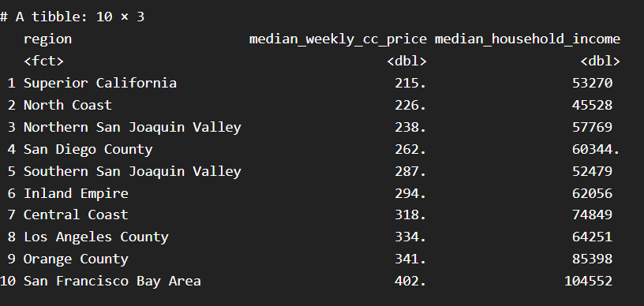

```r
#Lab 4 Question 5
income_cc <- ca_childcare |>
  filter(study_year == 2018) |>
  group_by(region) |>
  summarize(median_weekly_cc_price = median(mc_infant)) |>
  arrange(median_weekly_cc_price) |>
  inner_join(select(median_inc, -`2008`)) |>
  rename(median_household_income =`2018`)

income_cc
```

- Example 2

Output:

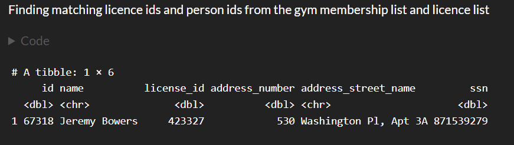

```r
#Lab 5 'Filtering the person table'

person |>
  filter(id %in% person_ids,
         license_id %in% licence_id)
```

**DVS-7: I show creativity in my tables.**

- Example 1
- Example 2

## Program Efficiency

**PE-1: I can write concise code which does not repeat itself.**

- using a single function call with multiple inputs (rather than multiple function calls)

```r
#Lab 4 Question 3
#Used mutate str_remove and fct_collapse inputs

ca_childcare <- ca_childcare |>
  mutate(county_name = str_remove(county_name, " County"),
        region = fct_collapse(county_name,
        "Superior California" = c("Butte", "El Dorado", "Colusa", "Glenn", "Lassen", "Modoc", "Nevada", "Placer", "Plumas", "Sacramento", "Shasta", "Sierra", "Siskiyou", "Sutter", "Tehama", "Yolo", "Yuba"),
        "North Coast" = c("Del Norte", "Humboldt", "Lake", "Mendocino", "Napa", "Sonoma", "Trinity"),
        "San Francisco Bay Area" = c("Alameda", "Contra Costa", "Marin", "San Francisco", "San Mateo", "Santa Clara", "Solano"),
        "Northern San Joaquin Valley" = c("Alpine", "Amador", "Calaveras", "Madera", "Mariposa", "Merced", "Mono", "San Joaquin", "Stanislaus", "Tuolumne"),
        "Central Coast" = c("Monterey", "San Benito", "San Luis Obispo", "Santa Barbara", "Santa Cruz", "Ventura"),
        "Southern San Joaquin Valley" = c("Fresno", "Inyo", "Kern", "Kings", "Tulare"),
        "Inland Empire" = c("Riverside", "San Bernardino"),
        "Los Angeles County" = "Los Angeles",
        "Orange County" = "Orange",
        "San Diego County" = c("Imperial", "San Diego")
        ), .before = state_abbreviation)
```

- `across()`
- `map()` functions

**PE-2: I can write functions to reduce repetition in my code.**

- Function that operates on vectors
- Function that operates on data frames

**PE-3:I can use iteration to reduce repetition in my code.**

- `across()`
- `map()` function with **one** input (e.g., `map()`, `map_chr()`, `map_dbl()`, etc.)
- `map()` function with **more than one** input (e.g., `map_2()` or `pmap()`)

**PE-4: I can use modern tools when carrying out my analysis.**

- I can use functions which are not superseded or deprecated

```r
#Lab 3 Question 7
#Modified orignal submission to include keyword arguments (such as .cols, .fns) for increased readibility
evals_cleaned |>
  filter(if_any(.cols = everything(), .fns = ~ is.na(.x)))
```

- I can connect a data wrangling pipeline into a `ggplot()`

```r
#Lab 4 Question 7
#Modified question to make the data wrangling pipeline connect directly to ggplot instead of storing a variable

ca_childcare |>
  filter(study_year == 2018) |>
  ggplot(mapping = aes(y = mc_infant,
                       x = mhi_2018)) +
  geom_point() +
  geom_smooth(method = "lm")
```

## Data Simulation & Statisical Models

**DSSM-1: I can simulate data from a *variety* of probability models.**

- Example 1
- Example 2

**DSSM-2: I can conduct common statistical analyses in R.**

- Example 1

```r
# Lab 4 Question 8

reg_mod1 <- lm(ca_childcare_2018$mc_infant ~ ca_childcare_2018$mhi_2018)
summary(reg_mod1)
```

- Example 2

```r
# Lab 2 Question 17

species_mod <- aov(data = surveys,
                   weight ~ species)

summary(species_mod)
```